# Week 4 - Filling in Values

Chris Healey

# Introduction

This week, we’ll be working with a US Higher Education dataset.

The main objectives we will cover will be:

- filtering columns
- handling different types of “NA” values
- correcting the types for columns after ingestion

# Import Data

Source: https://data.ed.gov/dataset/college-scorecard-all-data-files-through-6-2020/resources (retrieved November 16, 2021)

## Import each file

```r
library(tidyverse)
library(stringr)
library(skimr)
df = read_csv("data/MERGED2019_20_PP.csv")
dictionary = read_csv("data/collegescorecarddatadictionary.csv")
```

# Filtering columns

My aim is not to create an exhaustive list of all of the operations you might require, but to make sure that you have a few different code examples to use in your projects

## Creating new columns

We talked about assigning columns and using the `mutate` function back in week one.

```r
# if you look in the dictionary you'll see that the value "30" for column "RELAFFIL" denotes a college with a Catholic affliation
df$catholic <- ifelse(df$RELAFFIL=="30",TRUE,FALSE)
sum(df$catholic)
```

```
## [1] 244
```

```r
df %>% mutate(catholic = ifelse(RELAFFIL=="30",TRUE,FALSE))
```

```
## # A tibble: 6,694 x 2,393
##    UNITID OPEID    OPEID6 INSTNM  CITY  STABBR ZIP   ACCREDAGENCY INSTURL NPCURL
##     <dbl> <chr>    <chr>  <chr>   <chr> <chr>  <chr> <chr>        <chr>   <chr>
##  1 100654 00100200 001002 Alabam~ Norm~ AL     35762 Southern As~ www.aa~ www.a~
##  2 100663 00105200 001052 Univer~ Birm~ AL     3529~ Southern As~ https:~ https~
##  3 100690 02503400 025034 Amridg~ Mont~ AL     3611~ Southern As~ www.am~ www2.~
##  4 100706 00105500 001055 Univer~ Hunt~ AL     35899 Southern As~ www.ua~ finai~
##  5 100724 00100500 001005 Alabam~ Mont~ AL     3610~ Southern As~ www.al~ www.a~
##  6 100751 00105100 001051 The Un~ Tusc~ AL     3548~ Southern As~ www.ua~ finan~
##  7 100760 00100700 001007 Centra~ Alex~ AL     35010 Southern As~ www.ca~ https~
##  8 100812 00100800 001008 Athens~ Athe~ AL     35611 Southern As~ www.at~ www.a~
##  9 100830 00831000 008310 Auburn~ Mont~ AL     3611~ Southern As~ www.au~ www.a~
## 10 100858 00100900 001009 Auburn~ Aubu~ AL     36849 Southern As~ www.au~ https~
## # ... with 6,684 more rows, and 2,383 more variables: SCH_DEG <chr>,
## #   HCM2 <dbl>, MAIN <dbl>, NUMBRANCH <dbl>, PREDDEG <dbl>, HIGHDEG <dbl>,
## #   CONTROL <dbl>, ST_FIPS <dbl>, REGION <dbl>, LOCALE <chr>, LOCALE2 <chr>,
## #   LATITUDE <chr>, LONGITUDE <chr>, CCBASIC <chr>, CCUGPROF <chr>,
## #   CCSIZSET <chr>, HBCU <chr>, PBI <chr>, ANNHI <chr>, TRIBAL <chr>,
## #   AANAPII <chr>, HSI <chr>, NANTI <chr>, MENONLY <chr>, WOMENONLY <chr>,
## #   RELAFFIL <chr>, ADM_RATE <chr>, ADM_RATE_ALL <chr>, SATVR25 <chr>, ...
```

```r
sum(df$catholic)
```

```
## [1] 244
```

## Removing columns

```r
df_test <- df
df_test$PCIP01 <- NULL
df_test[c("PCIP02","PCIP03")] <-NULL
```

## Examples for filtering columns

A great alternative to choose (or drop) columns (subsets of your original data) is using the `select()` function from `dplyr`. Note `select` also can be used to reorder the columns within your dataframe, something I find useful before exporting.

### By type

```r
df_test <- df %>% select(where(is.numeric))
print(df_test)
```

```
## # A tibble: 6,694 x 13
##    UNITID  HCM2  MAIN NUMBRANCH PREDDEG HIGHDEG CONTROL ST_FIPS REGION CURROPER
##     <dbl> <dbl> <dbl>     <dbl>   <dbl>   <dbl>   <dbl>   <dbl>  <dbl>    <dbl>
##  1 100654     0     1         1       3       4       1       1      5        1
##  2 100663     0     1         1       3       4       1       1      5        1
##  3 100690     0     1         1       2       4       2       1      5        1
##  4 100706     0     1         1       3       4       1       1      5        1
##  5 100724     0     1         1       3       4       1       1      5        1
##  6 100751     0     1         1       3       4       1       1      5        1
##  7 100760     0     1         1       2       2       1       1      5        1
##  8 100812     0     1         1       3       4       1       1      5        1
##  9 100830     0     1         1       3       4       1       1      5        1
## 10 100858     0     1         1       3       4       1       1      5        1
## # ... with 6,684 more rows, and 3 more variables: ICLEVEL <dbl>, OPEFLAG <dbl>,
## #   DOLPROVIDER <dbl>
```

```r
df_test <- df %>% select_if(is.numeric)
print(df_test)
```

```
## # A tibble: 6,694 x 13
##    UNITID  HCM2  MAIN NUMBRANCH PREDDEG HIGHDEG CONTROL ST_FIPS REGION CURROPER
##     <dbl> <dbl> <dbl>     <dbl>   <dbl>   <dbl>   <dbl>   <dbl>  <dbl>    <dbl>
##  1 100654     0     1         1       3       4       1       1      5        1
##  2 100663     0     1         1       3       4       1       1      5        1
##  3 100690     0     1         1       2       4       2       1      5        1
##  4 100706     0     1         1       3       4       1       1      5        1
##  5 100724     0     1         1       3       4       1       1      5        1
##  6 100751     0     1         1       3       4       1       1      5        1
##  7 100760     0     1         1       2       2       1       1      5        1
##  8 100812     0     1         1       3       4       1       1      5        1
##  9 100830     0     1         1       3       4       1       1      5        1
## 10 100858     0     1         1       3       4       1       1      5        1
## # ... with 6,684 more rows, and 3 more variables: ICLEVEL <dbl>, OPEFLAG <dbl>,
## #   DOLPROVIDER <dbl>
```

### By name

```r
df_test <- df %>% select(c("UNITID","OPEID","INSTNM"))
print(df_test)
```

```
## # A tibble: 6,694 x 3
##    UNITID OPEID    INSTNM
##     <dbl> <chr>    <chr>
##  1 100654 00100200 Alabama A & M University
##  2 100663 00105200 University of Alabama at Birmingham
##  3 100690 02503400 Amridge University
##  4 100706 00105500 University of Alabama in Huntsville
##  5 100724 00100500 Alabama State University
##  6 100751 00105100 The University of Alabama
##  7 100760 00100700 Central Alabama Community College
##  8 100812 00100800 Athens State University
##  9 100830 00831000 Auburn University at Montgomery
## 10 100858 00100900 Auburn University
## # ... with 6,684 more rows
```

### By string

In many cases, you may want to manipulate or filter out columns that start with, end with, or contain strings. Use the `stringr` functions `starts_with()`, `ends_with()`, or `contains()`.

```r
df_test <- df %>% select(contains("SAT"))
print(df_test)
```

```
## # A tibble: 6,694 x 11
##    SATVR25 SATVR75 SATMT25 SATMT75 SATWR25 SATWR75 SATVRMID SATMTMID SATWRMID
##    <chr>   <chr>   <chr>   <chr>   <chr>   <chr>   <chr>    <chr>    <chr>
##  1 430     510     410     500     NULL    NULL    470      455      NULL
##  2 560     680     530     685     NULL    NULL    620      608      NULL
##  3 NULL    NULL    NULL    NULL    NULL    NULL    NULL     NULL     NULL
##  4 617     720     620     770     NULL    NULL    669      695      NULL
##  5 450     510     430     510     NULL    NULL    480      470      NULL
##  6 550     660     530     680     NULL    NULL    605      605      NULL
##  7 NULL    NULL    NULL    NULL    NULL    NULL    NULL     NULL     NULL
##  8 NULL    NULL    NULL    NULL    NULL    NULL    NULL     NULL     NULL
##  9 470     570     450     580     NULL    NULL    520      515      NULL
## 10 580     650     570     670     NULL    NULL    615      620      NULL
## # ... with 6,684 more rows, and 2 more variables: SAT_AVG <chr>,
## #   SAT_AVG_ALL <chr>
```

Combinations can also work:

```r
df_test <- df %>% select(c("UNITID","OPEID","INSTNM")|contains("SAT"))
print(df_test)
```

```
## # A tibble: 6,694 x 14
##    UNITID OPEID    INSTNM SATVR25 SATVR75 SATMT25 SATMT75 SATWR25 SATWR75 SATVRMID
##     <dbl> <chr>    <chr>  <chr>   <chr>   <chr>   <chr>   <chr>   <chr>   <chr>
##  1 100654 00100200 Alaba~ 430     510     410     500     NULL    NULL    470
##  2 100663 00105200 Unive~ 560     680     530     685     NULL    NULL    620
##  3 100690 02503400 Amrid~ NULL    NULL    NULL    NULL    NULL    NULL    NULL
##  4 100706 00105500 Unive~ 617     720     620     770     NULL    NULL    669
##  5 100724 00100500 Alaba~ 450     510     430     510     NULL    NULL    480
##  6 100751 00105100 The U~ 550     660     530     680     NULL    NULL    605
##  7 100760 00100700 Centr~ NULL    NULL    NULL    NULL    NULL    NULL    NULL
##  8 100812 00100800 Athen~ NULL    NULL    NULL    NULL    NULL    NULL    NULL
##  9 100830 00831000 Aubur~ 470     570     450     580     NULL    NULL    520
## 10 100858 00100900 Aubur~ 580     650     570     670     NULL    NULL    615
## # ... with 6,684 more rows, and 4 more variables: SATMTMID <chr>,
## #   SATWRMID <chr>, SAT_AVG <chr>, SAT_AVG_ALL <chr>
```

### By value

I want to share two cases for values. First we will search for all columns which feature a specific value. For you, it could be all “0” or all “NULL”.

```r
not_all_null_string <- function(x){!all(ifelse(x=="NULL",TRUE,FALSE))}
df_test %>% select_if(not_all_null_string)
```

```
## # A tibble: 6,694 x 11
##    UNITID OPEID INSTNM SATVR25 SATVR75 SATMT25 SATMT75 SATVRMID SATMTMID SAT_AVG
##     <dbl> <chr> <chr>  <chr>   <chr>   <chr>   <chr>   <chr>    <chr>    <chr>
##  1 100654 0010~ Alaba~ 430     510     410     500     470      455      939
##  2 100663 0010~ Unive~ 560     680     530     685     620      608      1234
##  3 100690 0250~ Amrid~ NULL    NULL    NULL    NULL    NULL     NULL     NULL
##  4 100706 0010~ Unive~ 617     720     620     770     669      695      1319
##  5 100724 0010~ Alaba~ 450     510     430     510     480      470      946
##  6 100751 0010~ The U~ 550     660     530     680     605      605      1261
##  7 100760 0010~ Centr~ NULL    NULL    NULL    NULL    NULL     NULL     NULL
##  8 100812 0010~ Athen~ NULL    NULL    NULL    NULL    NULL     NULL     NULL
##  9 100830 0083~ Aubur~ 470     570     450     580     520      515      1082
## 10 100858 0010~ Aubur~ 580     650     570     670     615      620      1300
## # ... with 6,684 more rows, and 1 more variable: SAT_AVG_ALL <chr>
```

We haven’t corrected all of the “NULL” strings, so I will provide a code that checks `NA` as opposed to “NULL”.

```r
not_all_na <- function(x){!all(is.na(x))}
df_test %>% select_if(not_all_na)
```

```
## # A tibble: 6,694 x 14
##    UNITID OPEID    INSTNM SATVR25 SATVR75 SATMT25 SATMT75 SATWR25 SATWR75 SATVRMID
##     <dbl> <chr>    <chr>  <chr>   <chr>   <chr>   <chr>   <chr>   <chr>   <chr>
##  1 100654 00100200 Alaba~ 430     510     410     500     NULL    NULL    470
##  2 100663 00105200 Unive~ 560     680     530     685     NULL    NULL    620
##  3 100690 02503400 Amrid~ NULL    NULL    NULL    NULL    NULL    NULL    NULL
##  4 100706 00105500 Unive~ 617     720     620     770     NULL    NULL    669
##  5 100724 00100500 Alaba~ 450     510     430     510     NULL    NULL    480
##  6 100751 00105100 The U~ 550     660     530     680     NULL    NULL    605
##  7 100760 00100700 Centr~ NULL    NULL    NULL    NULL    NULL    NULL    NULL
##  8 100812 00100800 Athen~ NULL    NULL    NULL    NULL    NULL    NULL    NULL
##  9 100830 00831000 Aubur~ 470     570     450     580     NULL    NULL    520
## 10 100858 00100900 Aubur~ 580     650     570     670     NULL    NULL    615
## # ... with 6,684 more rows, and 4 more variables: SATMTMID <chr>,
## #   SATWRMID <chr>, SAT_AVG <chr>, SAT_AVG_ALL <chr>
```

# Looking through the data

```r
df_test %>% skim()
```

Data summary

| Name | Piped data |
| --- | --- |
| Number of rows | 6694 |
| Number of columns | 14 |
| _______________________ |  |
| Column type frequency: |  |
| character | 13 |
| numeric | 1 |
| ________________________ |  |
| Group variables | None |

**Variable type: character**

| skim_variable | n_missing | complete_rate | min | max | empty | n_unique | whitespace |
| --- | --- | --- | --- | --- | --- | --- | --- |
| OPEID | 0 | 1 | 8 | 8 | 0 | 6666 | 0 |
| INSTNM | 0 | 1 | 3 | 93 | 0 | 6571 | 0 |
| SATVR25 | 0 | 1 | 3 | 4 | 0 | 91 | 0 |
| SATVR75 | 0 | 1 | 3 | 4 | 0 | 90 | 0 |
| SATMT25 | 0 | 1 | 3 | 4 | 0 | 108 | 0 |
| SATMT75 | 0 | 1 | 3 | 4 | 0 | 90 | 0 |
| SATWR25 | 0 | 1 | 4 | 4 | 0 | 1 | 0 |
| SATWR75 | 0 | 1 | 4 | 4 | 0 | 1 | 0 |
| SATVRMID | 0 | 1 | 3 | 4 | 0 | 152 | 0 |
| SATMTMID | 0 | 1 | 3 | 4 | 0 | 162 | 0 |
| SATWRMID | 0 | 1 | 4 | 4 | 0 | 1 | 0 |
| SAT_AVG | 0 | 1 | 3 | 4 | 0 | 453 | 0 |
| SAT_AVG_ALL | 0 | 1 | 3 | 4 | 0 | 451 | 0 |

**Variable type: numeric**

| skim_variable | n_missing | complete_rate | mean | sd | p0 | p25 | p50 | p75 | p100 | hist |
| --- | --- | --- | --- | --- | --- | --- | --- | --- | --- | --- |
| UNITID | 0 | 1 | 2264647 | 7878432 | 100654 | 174140.5 | 228648.5 | 455270.5 | 49175601 | ▇▁▁▁▁ |

As you can see, there’s a lot of information that should be numeric here, but `read_csv` isn’t handling “NULL” correctly.

## Fixing NULLs

We have a couple of options.

### Correct at ingestion

```r
df_null = read_csv("data/MERGED2019_20_PP.csv", na=c("","na","NULL"))
df_null_test <- df_null %>% select(c("UNITID","OPEID","INSTNM")|contains("SAT"))
df_null_test %>% skim()
```

Data summary

| Name | Piped data |
| --- | --- |
| Number of rows | 6694 |
| Number of columns | 14 |
| _______________________ |  |
| Column type frequency: |  |
| character | 2 |
| logical | 3 |
| numeric | 9 |
| ________________________ |  |
| Group variables | None |

**Variable type: character**

| skim_variable | n_missing | complete_rate | min | max | empty | n_unique | whitespace |
| --- | --- | --- | --- | --- | --- | --- | --- |
| OPEID | 0 | 1 | 8 | 8 | 0 | 6666 | 0 |
| INSTNM | 0 | 1 | 3 | 93 | 0 | 6571 | 0 |

**Variable type: logical**

| skim_variable | n_missing | complete_rate | mean | count |
| --- | --- | --- | --- | --- |
| SATWR25 | 6694 | 0 | NaN | : |
| SATWR75 | 6694 | 0 | NaN | : |
| SATWRMID | 6694 | 0 | NaN | : |

**Variable type: numeric**

| skim_variable | n_missing | complete_rate | mean | sd | p0 | p25 | p50 | p75 | p100 | hist |
| --- | --- | --- | --- | --- | --- | --- | --- | --- | --- | --- |
| UNITID | 0 | 1.00 | 2264646.64 | 7878432.10 | 100654 | 174140.5 | 228648.5 | 455270.5 | 49175601 | ▇▁▁▁▁ |
| SATVR25 | 5476 | 0.18 | 516.25 | 66.40 | 280 | 470.0 | 500.0 | 550.0 | 740 | ▁▃▇▂▁ |
| SATVR75 | 5476 | 0.18 | 615.35 | 60.47 | 330 | 580.0 | 610.0 | 650.0 | 790 | ▁▁▇▇▂ |
| SATMT25 | 5476 | 0.18 | 510.91 | 73.38 | 230 | 460.0 | 500.0 | 540.0 | 790 | ▁▂▇▂▁ |
| SATMT75 | 5476 | 0.18 | 612.60 | 74.15 | 401 | 560.0 | 600.0 | 650.0 | 800 | ▁▅▇▃▂ |
| SATVRMID | 5476 | 0.18 | 565.83 | 62.42 | 305 | 525.0 | 555.0 | 600.0 | 755 | ▁▁▇▅▁ |
| SATMTMID | 5476 | 0.18 | 561.79 | 72.70 | 320 | 515.0 | 550.0 | 595.0 | 795 | ▁▃▇▂▁ |
| SAT_AVG | 5416 | 0.19 | 1139.94 | 130.13 | 737 | 1053.0 | 1118.0 | 1204.0 | 1557 | ▁▅▇▂▁ |
| SAT_AVG_ALL | 5266 | 0.21 | 1145.91 | 128.73 | 737 | 1059.0 | 1127.0 | 1214.0 | 1557 | ▁▅▇▂▁ |

### Correct NULL and then re-run type assignment

```r
df_rewrite_test = df_test
df_rewrite_test[df_rewrite_test == "NULL"] <- NA
df_rewrite_test = type_convert(df_rewrite_test)
```

### Apply `parse_integer` on each column

Not a great solution, but can work for small cases…

```r
df_parse_test = df_test
df_parse_test$SATVR25 = parse_integer(df_test$SATVR25, na=c("NULL"))
summary(df_parse_test$SATVR25)
```

[output not shown]

# A visualization

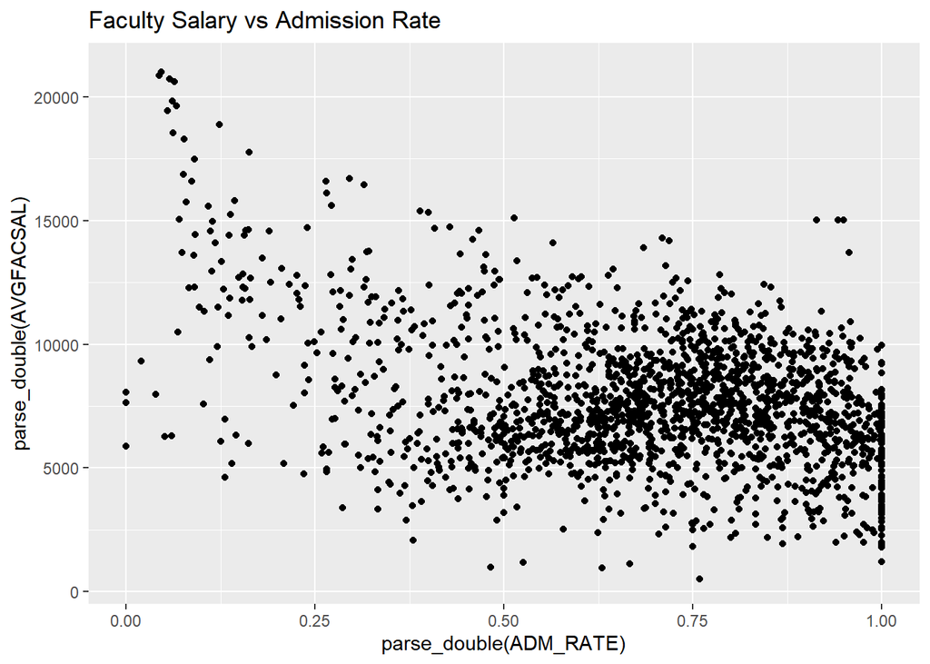

```r
library(ggplot2)
g<-ggplot(data=df)+geom_point(aes(x=parse_double(ADM_RATE),y=parse_double(AVGFACSAL)))+ggtitle("Faculty Salary vs Admission Rate")
print(g)
```